# customer churn

```python
import pandas as pd
import numpy as np
import seaborn as sns
import matplotlib.pyplot as plt
import random
import scipy.stats as stats
import warnings
warnings.filterwarnings("ignore")
```

```python
customer_data = pd.read_csv("C:/Users/User/Downloads/customer_churn_dataset.csv")
```

```python
customer_data.isnull().sum()
```

```
CustomerID         0
Gender             0
Age                0
Tenure             0
ContractType       0
MonthlyCharges     0
InternetService    0
SupportCalls       0
TotalCharges       0
Churn              0
dtype: int64
```

```python
customer_data.head()
```

|  | CustomerID | Gender | Age | Tenure | ContractType | MonthlyCharges | InternetService | SupportCalls | TotalCharges | Churn |
| --- | --- | --- | --- | --- | --- | --- | --- | --- | --- | --- |
| 0 | 1 | Male | 41 | 25 | Month-to-Month | 68.55 | Fiber optic | 3 | 1729.08 | No |
| 1 | 2 | Female | 26 | 59 | Two Year | 54.84 | Fiber optic | 0 | 3224.04 | No |
| 2 | 3 | Male | 52 | 17 | Month-to-Month | 79.06 | Fiber optic | 1 | 1388.55 | No |
| 3 | 4 | Male | 68 | 55 | Two Year | 60.23 | No | 3 | 3284.43 | No |
| 4 | 5 | Male | 37 | 30 | Month-to-Month | 55.96 | DSL | 0 | 1730.67 | No |

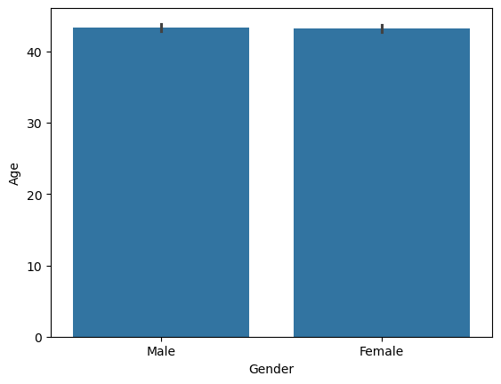

```python
sns.barplot(x= "Gender",y = "Age",data = customer_data)
```

```python
customer_data.duplicated().sum()
```

```
0
```

```python
num_cols = customer_data.select_dtypes(include = np.number).columns
```

```python
num_cols
```

```
Index(['CustomerID', 'Age', 'Tenure', 'MonthlyCharges', 'SupportCalls',
       'TotalCharges'],
      dtype='object')
```

```
<function matplotlib.pyplot.show(close=None, block=None)>
```

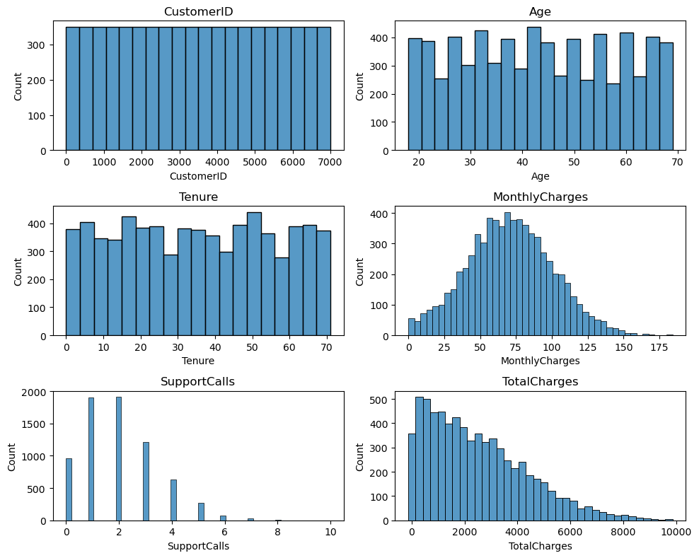

```python
plt.figure(figsize = (10,8))
a=3
b=2
c=1
for i in  num_cols:
    plt.subplot(a,b,c)
    sns.histplot(customer_data[i])
    c+=1
    plt.title(i)
plt.tight_layout()
plt.show
```

```python
cat_cols= customer_data.select_dtypes(include="object").columns
```

```python
cat_cols
```

```
Index(['Gender', 'ContractType', 'InternetService', 'Churn'], dtype='object')
```

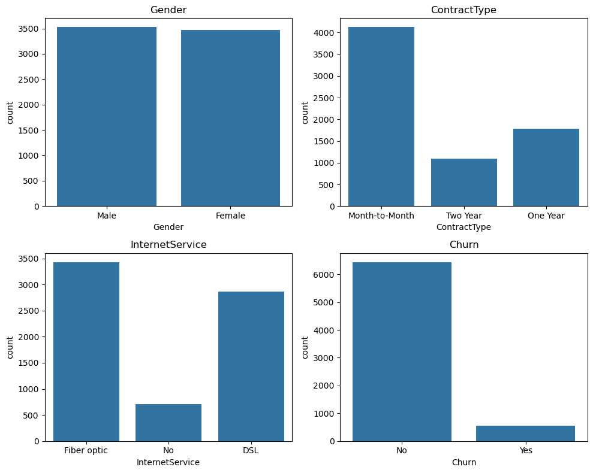

```python
plt.figure(figsize= (10,8))
a=2
b=2
c=1
for i in cat_cols:
    plt.subplot(a,b,c)
    sns.countplot(x=customer_data[i])
    c+=1
    plt.title(i)
plt.tight_layout()
plt.show()
```

```python
customer_data.head(1)
```

|  | CustomerID | Gender | Age | Tenure | ContractType | MonthlyCharges | InternetService | SupportCalls | TotalCharges | Churn |
| --- | --- | --- | --- | --- | --- | --- | --- | --- | --- | --- |
| 0 | 1 | Male | 41 | 25 | Month-to-Month | 68.55 | Fiber optic | 3 | 1729.08 | No |

# Probability

```python
ci = 0.95
alpha = 1-ci
z_critic = stats.norm.isf(alpha/2)
z_critic
```

```
1.959963984540054
```

```python
moe = 0.05
e = 5
```

```python
std = np.std(customer_data["Tenure"])
```

```python
n = (np.square(z_critic)* np.square(std))
```

```python
round(n/25)
```

```
66
```

```python
customer_data.value_counts().sum()
```

```
7000
```

```python
sample = customer_data.sample(n=66,random_state=42)
```

```python
sample["Gender"].unique()
```

```
array(['Female', 'Male'], dtype=object)
```

```python
(sample["Gender"]=="Male").value_counts()
```

```
Gender
True     36
False    30
Name: count, dtype: int64
```

```python
male = customer_data.loc[customer_data["Gender"]=="Male"]
female = customer_data.loc[customer_data["Gender"]=="Female"]
```

```python
f= female.value_counts().sum()
overall= customer_data.value_counts().sum()
```

```python
f
```

```
3473
```

```python
p = f/overall
p
```

```
0.49614285714285716
```

made a sample data of 66 rows find how much are female

we don't have success rate

```python
mew = np.mean(customer_data["MonthlyCharges"])
xbar = np.mean(sample["MonthlyCharges"])
```

```python
mew,xbar
```

```
(70.69202428571428, 70.6269696969697)
```

```python
zscore = xbar-mew/std
```

```python
zscore
```

```
67.22146807605995
```

```python
stats.norm.cdf(zscore)
```

```
1.0
```

cdf(z) = 0.5 → z-score is at the mean (middle of distribution).

cdf(z) < 0.5 → z-score is below the mean.

cdf(z) > 0.5 → z-score is above the mean.

cdf(z) ≈ 1 → z-score is far in the right tail, almost all values are below it.

cdf(z) ≈ 0 → z-score is far in the left tail, almost all values are above it.

probability of females in sample is

```python
sc = sample.value_counts().sum()
fc = sample.loc[sample["Gender"]== "Female"].value_counts().sum()
```

```python
sc
```

```
66
```

```python
fc/sc
```

```
0.45454545454545453
```

```python
fc
```

```
30
```

```python
sample.loc[sample["Gender"]=="Female"].value_counts().sum()
```

```
30
```

```python
sample.value_counts().sum()
```

```
66
```

```python
sample["Gender"].unique()
```

```
array(['Female', 'Male'], dtype=object)
```

```python
sam = customer_data.sample(n=66,random_state=42)
```

```python
sam
```

|  | CustomerID | Gender | Age | Tenure | ContractType | MonthlyCharges | InternetService | SupportCalls | TotalCharges | Churn |
| --- | --- | --- | --- | --- | --- | --- | --- | --- | --- | --- |
| 6500 | 6501 | Female | 21 | 21 | Month-to-Month | 52.42 | DSL | 3 | 1026.34 | No |
| 2944 | 2945 | Female | 51 | 55 | Month-to-Month | 118.21 | Fiber optic | 2 | 6495.17 | No |
| 2024 | 2025 | Male | 23 | 38 | One Year | 80.36 | Fiber optic | 3 | 3074.60 | No |
| 263 | 264 | Male | 26 | 7 | Month-to-Month | 97.80 | DSL | 3 | 665.30 | Yes |
| 4350 | 4351 | Female | 41 | 39 | One Year | 69.79 | DSL | 1 | 2621.19 | No |
| ... | ... | ... | ... | ... | ... | ... | ... | ... | ... | ... |
| 3880 | 3881 | Female | 38 | 26 | Month-to-Month | 47.48 | DSL | 3 | 1206.22 | No |
| 1074 | 1075 | Male | 41 | 15 | One Year | 97.61 | DSL | 2 | 1520.45 | No |
| 3966 | 3967 | Male | 18 | 11 | Two Year | 101.21 | No | 5 | 1206.96 | Yes |
| 2549 | 2550 | Male | 43 | 31 | One Year | 80.16 | Fiber optic | 3 | 2530.48 | No |
| 4927 | 4928 | Female | 18 | 54 | Month-to-Month | 42.30 | DSL | 2 | 2253.62 | No |

66 rows × 10 columns

```python
(sam["Gender"]=="Male").sum()
```

```
36
```

```python
churn = customer_data["Churn"]
contract_type = customer_data["ContractType"]
```

# Chi Square test

Ho => churn and contract_type are independent

Ha => they are dependent

```python
tbl = pd.crosstab(churn,contract_type)
```

```python
test_stats,pvalue,dof,expected_freq = stats.chi2_contingency(tbl)
```

```python
print(test_stats,pvalue)
```

```
4.684498281700059 0.09611122726496203
```

# T Test

Is the average MonthlyCharges of our sample significantly different from a hypothesized value (e.g., ₹70)?

Ho = monthly salary is equal to 70

Ha = monthly salary is not equal to 70

```python
stats.ttest_1samp(customer_data["MonthlyCharges"],70)
```

```
TtestResult(statistic=1.949645449693226, pvalue=0.05125827295202869, df=6999)
```

```python
customer_data.tail()
```

|  | CustomerID | Gender | Age | Tenure | ContractType | MonthlyCharges | InternetService | SupportCalls | TotalCharges | Churn |
| --- | --- | --- | --- | --- | --- | --- | --- | --- | --- | --- |
| 6995 | 6996 | Female | 45 | 2 | One Year | 30.70 | Fiber optic | 2 | 101.88 | No |
| 6996 | 6997 | Female | 47 | 52 | Month-to-Month | 50.21 | DSL | 1 | 2651.38 | No |
| 6997 | 6998 | Male | 35 | 37 | One Year | 70.32 | DSL | 2 | 2621.36 | No |
| 6998 | 6999 | Male | 61 | 50 | Month-to-Month | 100.77 | DSL | 3 | 5087.94 | No |
| 6999 | 7000 | Male | 44 | 14 | One Year | 24.39 | Fiber optic | 1 | 477.74 | No |

Do Month-to-Month and One Year contract customers differ significantly in MonthlyCharges

```python
mt = customer_data.loc[customer_data["ContractType"]=="Month-to-Month"]["MonthlyCharges"]
o = customer_data.loc[customer_data["ContractType"]=="One Year"]["MonthlyCharges"]
```

```python
o.head()
```

```
6     113.98
9      67.11
11     72.23
17     26.18
20     65.09
Name: MonthlyCharges, dtype: float64
```

```python
stats.ttest_ind(mt,o)
```

```
TtestResult(statistic=-0.024635060356427582, pvalue=0.9803468860668396, df=5905.0)
```

```python
customer_data.head()
```

|  | CustomerID | Gender | Age | Tenure | ContractType | MonthlyCharges | InternetService | SupportCalls | TotalCharges | Churn |
| --- | --- | --- | --- | --- | --- | --- | --- | --- | --- | --- |
| 0 | 1 | Male | 41 | 25 | Month-to-Month | 68.55 | Fiber optic | 3 | 1729.08 | No |
| 1 | 2 | Female | 26 | 59 | Two Year | 54.84 | Fiber optic | 0 | 3224.04 | No |
| 2 | 3 | Male | 52 | 17 | Month-to-Month | 79.06 | Fiber optic | 1 | 1388.55 | No |
| 3 | 4 | Male | 68 | 55 | Two Year | 60.23 | No | 3 | 3284.43 | No |
| 4 | 5 | Male | 37 | 30 | Month-to-Month | 55.96 | DSL | 0 | 1730.67 | No |

Z-test: Is the proportion of churned customers > 30%?

Ho = The churn proportion is 30%

Ha = is <> 30%

```python
from statsmodels.stats.weightstats import ztest
```

```python
z_critic = stats.norm.isf(alpha/2)
z_critic
```

```
1.959963984540054
```

```python
std = np.std(customer_data["MonthlyCharges"])
```

```python
np.mean(sample["MonthlyCharges"])
```

```
70.6269696969697
```

```python
np.mean(customer_data["MonthlyCharges"])
```

```
70.69202428571428
```

```python
xbar,mew
```

```
(70.6269696969697, 70.69202428571428)
```

```python
zteststats = (xbar-mew)/std/np.sqrt(n)
```

```python
z_critic,zteststats
```

```
(1.959963984540054, -5.384641896823008e-05)
```

```python
u = customer_data.loc[customer_data["Churn"]=="Yes"]
```

```python
t = u.value_counts().sum()
t
```

```
561
```

```python
o = customer_data.value_counts().sum()
o
```

```
7000
```

```python
t/o
```

```
0.08014285714285714
```

T-test: Do customers with Month-to-Month contracts have higher monthly charges than those with Two-Year contracts?

Ha = Customer month to month and two years have same monthly salary

Ho = Customer month to month have heigher salary

```python
customer_data.head()
```

|  | CustomerID | Gender | Age | Tenure | ContractType | MonthlyCharges | InternetService | SupportCalls | TotalCharges | Churn |
| --- | --- | --- | --- | --- | --- | --- | --- | --- | --- | --- |
| 0 | 1 | Male | 41 | 25 | Month-to-Month | 68.55 | Fiber optic | 3 | 1729.08 | No |
| 1 | 2 | Female | 26 | 59 | Two Year | 54.84 | Fiber optic | 0 | 3224.04 | No |
| 2 | 3 | Male | 52 | 17 | Month-to-Month | 79.06 | Fiber optic | 1 | 1388.55 | No |
| 3 | 4 | Male | 68 | 55 | Two Year | 60.23 | No | 3 | 3284.43 | No |
| 4 | 5 | Male | 37 | 30 | Month-to-Month | 55.96 | DSL | 0 | 1730.67 | No |

```python
e = customer_data.loc[customer_data["ContractType"] == "Month-to-Month"]["MonthlyCharges"]
```

```python
m =  customer_data.loc[customer_data["ContractType"] == "Two Year"]["MonthlyCharges"]
```

```python
stats.ttest_ind(e,m)
```

```
TtestResult(statistic=-2.178789684488763, pvalue=0.02939189196034695, df=5218.0)
```

Chi-square test: Is churn independent of gender?

Ho = both are independent

Ha = both are dependent

```python
g = customer_data["Gender"]
```

```python
c = customer_data["Churn"]
```

```python
tb = pd.crosstab(g,c)
```

```python
testst,p_val,dof,expected= stats.chi2_contingency(tb)
```

```python
testst,p_val
```

```
(0.29451520432307976, 0.5873415042133466)
```

ANOVA: Is there a significant difference in average monthly charges across ContractType?

Ho = averagemonthly salary are same for all contract

Ha = average are not same

```python
import statsmodels.api as sma
from statsmodels.formula.api import ols
```

```python
model = ols('MonthlyCharges~ C(ContractType)',data = customer_data).fit()
```

```python
sma.stats.anova_lm(model)
```

|  | df | sum_sq | mean_sq | F | PR(>F) |
| --- | --- | --- | --- | --- | --- |
| C(ContractType) | 2.0 | 4.384911e+03 | 2192.455341 | 2.487058 | 0.083228 |
| Residual | 6997.0 | 6.168177e+06 | 881.545886 | NaN | NaN |

What is the correlation between Tenure and MonthlyCharges?

```python
customer_data.loc[:,["Tenure","MonthlyCharges"]].corr()
```

|  | Tenure | MonthlyCharges |
| --- | --- | --- |
| Tenure | 1.000000 | -0.026473 |
| MonthlyCharges | -0.026473 | 1.000000 |

```python
stats.shapiro(customer_data["MonthlyCharges"])
```

```
ShapiroResult(statistic=0.9974816966268687, pvalue=2.0627051287038347e-09)
```

```python
stats.shapiro(customer_data["TotalCharges"])
```

```
ShapiroResult(statistic=0.9369053559224376, pvalue=2.0360801959073483e-47)
```

```python
stats.levene(customer_data["MonthlyCharges"],customer_data["TotalCharges"])
```

```
LeveneResult(statistic=11081.217566020412, pvalue=0.0)
```

```python
num_cols
```

```
Index(['CustomerID', 'Age', 'Tenure', 'MonthlyCharges', 'SupportCalls',
       'TotalCharges'],
      dtype='object')
```

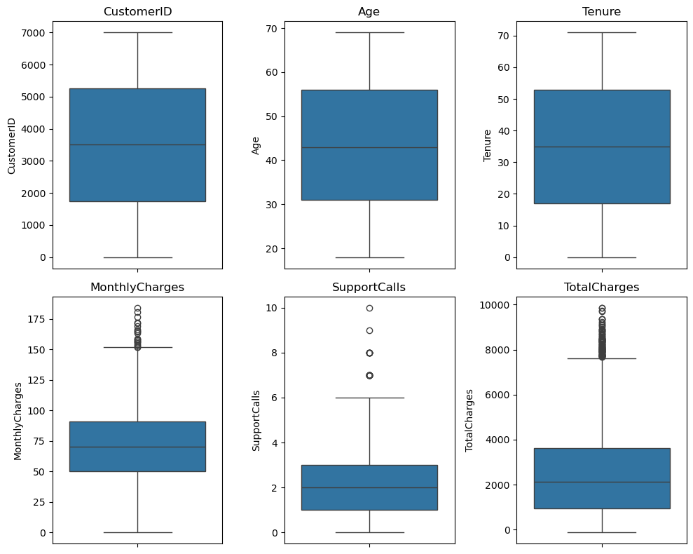

```python
plt.figure(figsize = (10,8))
a= 2
b = 3
c=1
for i in num_cols:
    plt.subplot(a,b,c)
    sns.boxplot(customer_data[i])
    c+=1
    plt.title(i)
plt.tight_layout()
plt.show()
```

```python
for i in num_cols:
    ll,ul = np.quantile(customer_data[i],[0.10,0.95])
    customer_data.loc[customer_data[i]>ul,i]=ul
    customer_data.loc[customer_data[i]<ll,i]=ll
```

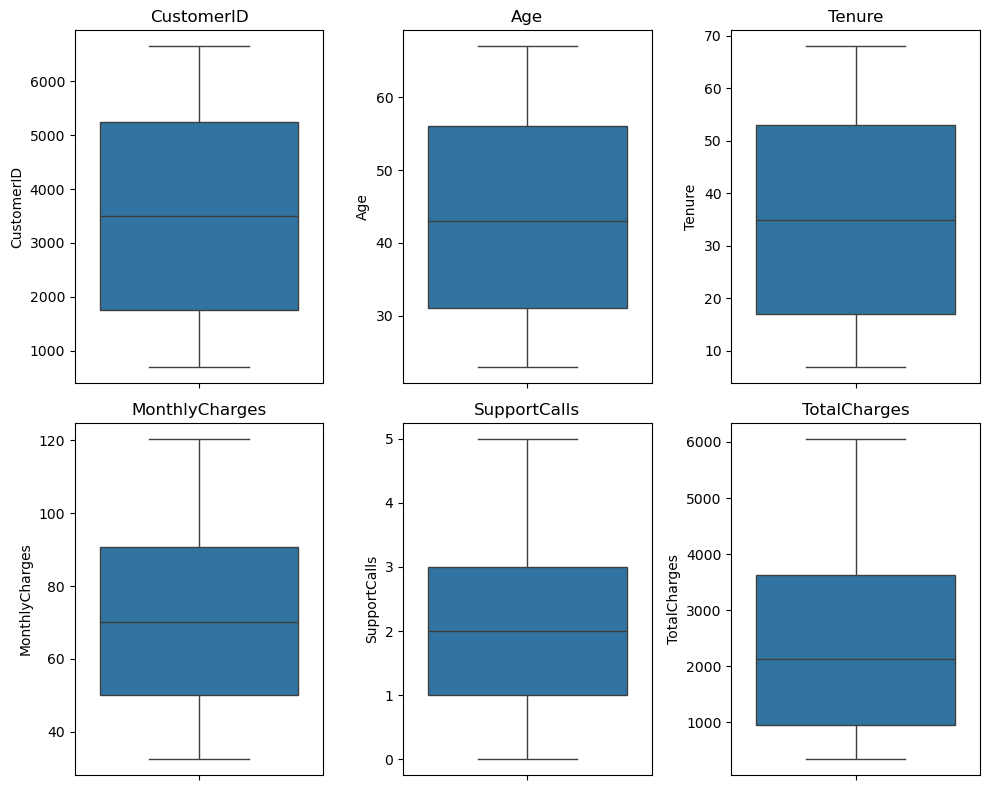

```python
plt.figure(figsize = (10,8))
a= 2
b = 3
c=1
for i in num_cols:
    plt.subplot(a,b,c)
    sns.boxplot(customer_data[i])
    c+=1
    plt.title(i)
plt.tight_layout()
plt.show()
```